# model2

# **Step 5 — Evaluate Need for Transformations (Individual Work)**

```r
# Log transforms
train_data$log_income      <- log(train_data$income)
train_data$log_share       <- log(train_data$share + 1)     # +1 if share has zeros
train_data$log_months      <- log(train_data$months)

# Sqrt transforms
train_data$sqrt_income <- sqrt(train_data$income)
train_data$sqrt_share  <- sqrt(train_data$share)
train_data$sqrt_months <- sqrt(train_data$months)

# Centering log transforms
train_data$log_income_c      <- train_data$log_income - mean(train_data$log_income)
train_data$log_income_c2     <- train_data$log_income_c^2

train_data$log_share_c       <- train_data$log_share - mean(train_data$log_share)
train_data$log_share_c2      <- train_data$log_share_c^2

train_data$log_months_c      <- train_data$log_months - mean(train_data$log_months)
train_data$log_months_c2     <- train_data$log_months_c^2

# Centering sqrt transforms
train_data$sqrt_income_c     <- train_data$sqrt_income - mean(train_data$sqrt_income)
train_data$sqrt_income_c2    <- train_data$sqrt_income_c^2

train_data$sqrt_share_c      <- train_data$sqrt_share - mean(train_data$sqrt_share)
train_data$sqrt_share_c2     <- train_data$sqrt_share_c^2

train_data$sqrt_months_c     <- train_data$sqrt_months - mean(train_data$sqrt_months)
train_data$sqrt_months_c2    <- train_data$sqrt_months_c^2
```

Based on previous analyses from last two weeks, we found that all variables that we are using, including both predictors and the response, are right-skewed. Furthermore, in part 2, we identified four variables, which are expenditure, income, share, and months, that exhibit curvature, violating the assumptions of normality and constant variance. Therefore, it is necessary to perform a transformation. Regarding Y, the expenditure, I will use Box-Cox transformation to assess whether transforming the response variable can improve these assumptions. Regarding X, I will explore potential transformations (such as log or square-root) for the three predictor variables.

```r
# box cox requires variables to be all positive, so we use log expenditure squared
bc <- boxcox(lm((expenditure+1) ~ income + share + dependents + months + active, data=train_data))
```

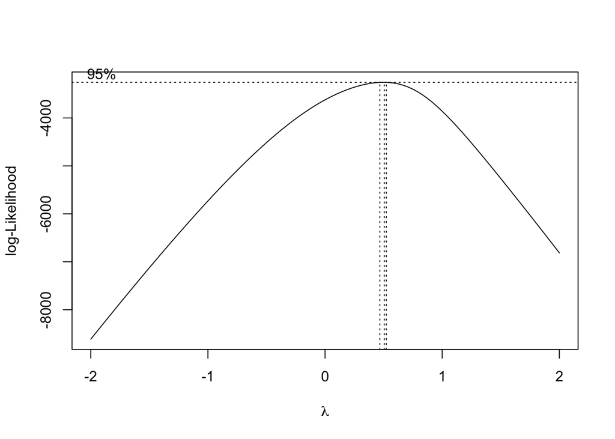

```r
lambda <- bc$x[which.max(bc$y)]
lambda # 0.5050505
```

```
## [1] 0.5050505
```

To address the issue of negative values existed in expenditure (Y), I applied Box-Cox to expenditure + 1 and found that the optimal lambda is 0.505. This result indicates that a square-root transformation of the response variable is most appropriate for stabilizing variance and improving the normality of residuals.

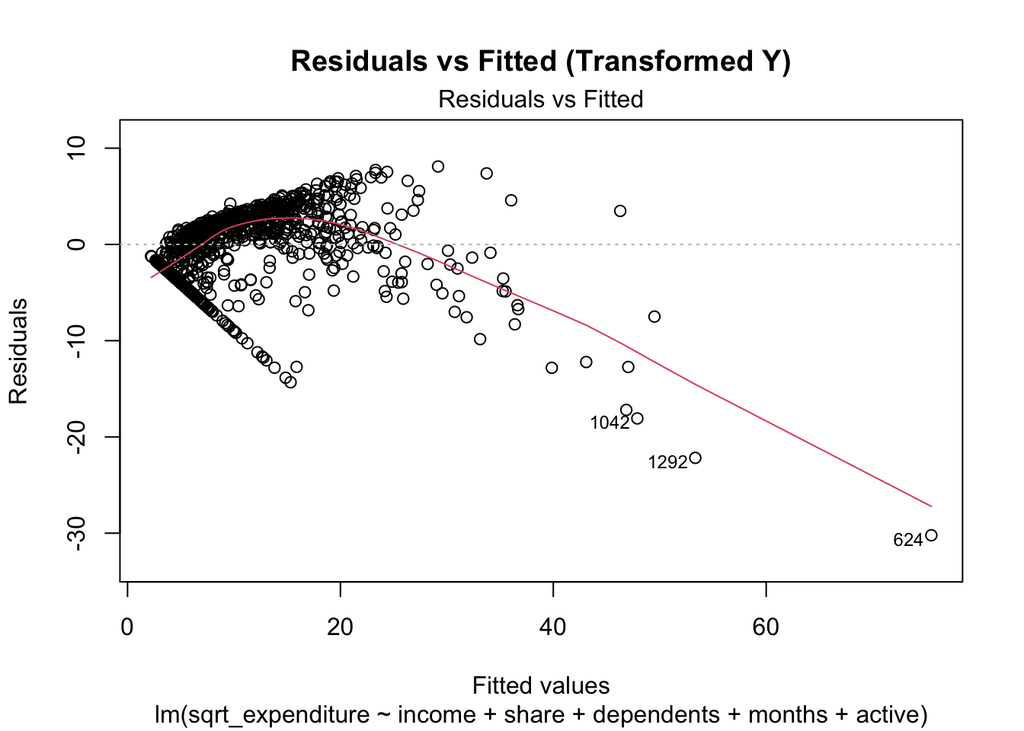

```r
train_data$sqrt_expenditure <- (train_data$expenditure + 1)^0.505

model_trans <- lm(sqrt_expenditure ~ income + share + dependents + months + active, data=train_data)

plot(model_trans, which=1, main="Residuals vs Fitted (Transformed Y)")
```

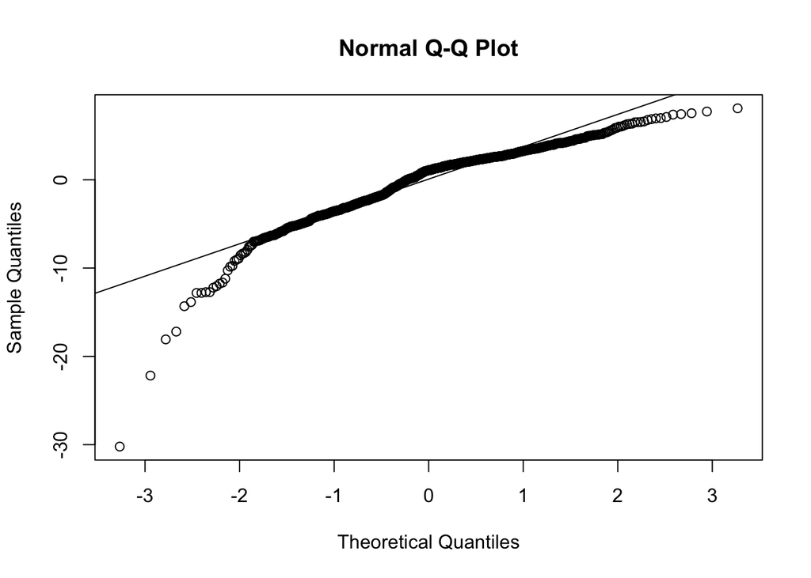

```r
qqnorm(resid(model_trans)); qqline(resid(model_trans), main="QQ Plot (Transformed Y)")
```

The plot diagnosises show that transform Y makes the situation worse. there is still a clear curvature exist in the residual vs fitted plot, and even more deviations in the QQ plot.

# **Step 6 — Build Your Refined Model (Individual Work)**

```r
# Interaction term, use the centered variable
train_data$income_c <- train_data$income - mean(train_data$income)
train_data$share_c <- train_data$share - mean(train_data$share)
train_data$income_months_share <- train_data$income_c * train_data$months * train_data$share_c
# Centered polynomial terms
train_data$income_c2 <- train_data$income_c^2
train_data$log_share_c2 <- train_data$log_share_c^2

refined_model3 <- lm(sqrt_expenditure ~ income_c + income_c2 + sqrt_share_c + log_share_c2 +
                     months + income_months_share + dependents + active,
                     data = train_data) # adjusted R^2: 0.971
summary(refined_model3)
```

```
##
## Call:
## lm(formula = sqrt_expenditure ~ income_c + income_c2 + sqrt_share_c +
##     log_share_c2 + months + income_months_share + dependents +
##     active, data = train_data)
##
## Residuals:
##     Min      1Q  Median      3Q     Max
## -7.4202 -0.5621 -0.0057  0.6437 10.5039
##
## Coefficients:
##                       Estimate Std. Error t value Pr(>|t|)
## (Intercept)          1.120e+01  9.856e-02 113.604  < 2e-16 ***
## income_c             1.672e+00  4.458e-02  37.512  < 2e-16 ***
## income_c2           -7.415e-02  1.080e-02  -6.864 1.23e-11 ***
## sqrt_share_c         5.241e+01  3.531e-01 148.416  < 2e-16 ***
## log_share_c2        -1.254e+01  3.097e+00  -4.050 5.56e-05 ***
## months               2.540e-03  7.475e-04   3.398 0.000709 ***
## income_months_share  7.872e-02  3.966e-03  19.850  < 2e-16 ***
## dependents           3.530e-02  4.136e-02   0.853 0.393634
## active               2.392e-03  7.651e-03   0.313 0.754633
## ---
## Signif. codes:  0 '***' 0.001 '**' 0.01 '*' 0.05 '.' 0.1 ' ' 1
##
## Residual standard error: 1.435 on 914 degrees of freedom
## Multiple R-squared:  0.9712, Adjusted R-squared:  0.971
## F-statistic:  3853 on 8 and 914 DF,  p-value: < 2.2e-16
```

```r
cat("The final refined model:\nAdjusted R^2: ", summary(refined_model3)$adj.r.square)
```

```
## The final refined model:
## Adjusted R^2:  0.9709521
```

```r
cat("\nVIF: \n")
```

```
##
## VIF:
```

```r
vif(refined_model3)
```

```
##            income_c           income_c2        sqrt_share_c        log_share_c2
##            2.526913            2.403627            1.392025            1.413630
##              months income_months_share          dependents              active
##            1.138728            1.280959            1.176237            1.041303
```

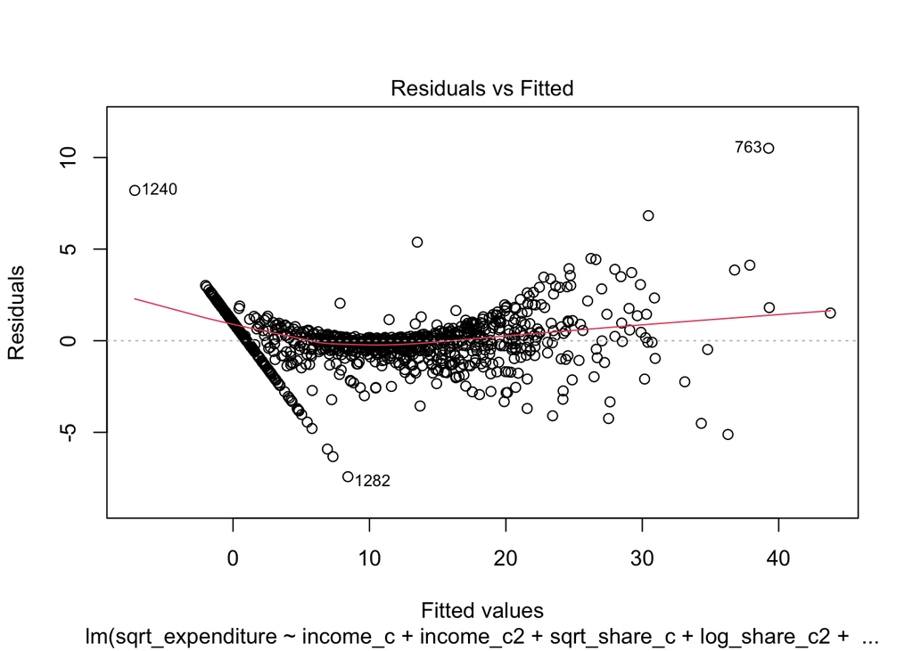

```r
# Check residuals
plot(refined_model3, which=1) # residuals vs fitted
```

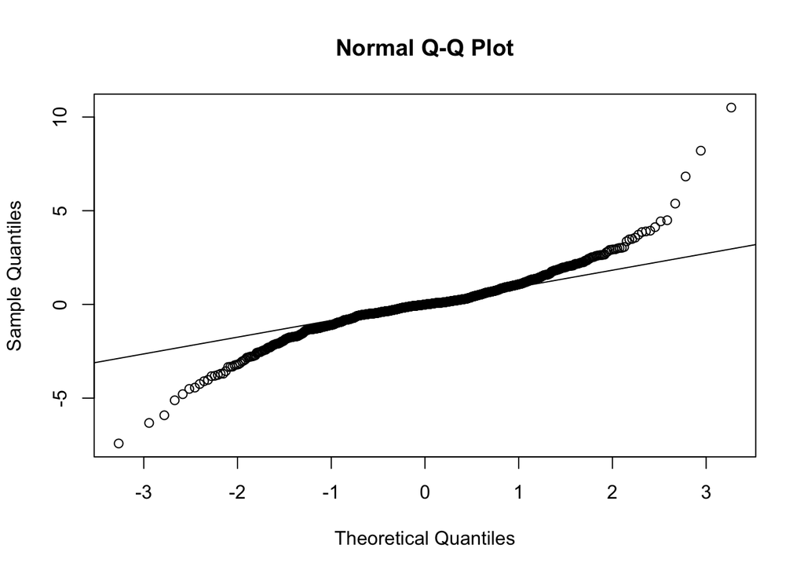

```r
qqnorm(resid(refined_model3)); qqline(resid(refined_model3)) # normality
```